# GO in the head

Diogo Melo

10/11/2021

## Reading GO enrichment object

```r
en_head = readRDS(here::here('data/enGo_head.Rds'))
```

## Level 3 blocks

```r
goplot_list = llply(en_head$summary$Name[en_head$summary$Nested_Level==3],
                    XGR_plot, en_head$XGR, en_head$summary)
```

```
## [1] "0-0"
## [1] "1-1"
## [1] "2-1"
## [1] "3-0"
## [1] "4-0"
```

```r
names(goplot_list) = en_head$summary$Name[en_head$summary$Nested_Level==3]
```

### 0-0 - Neuro and sensing

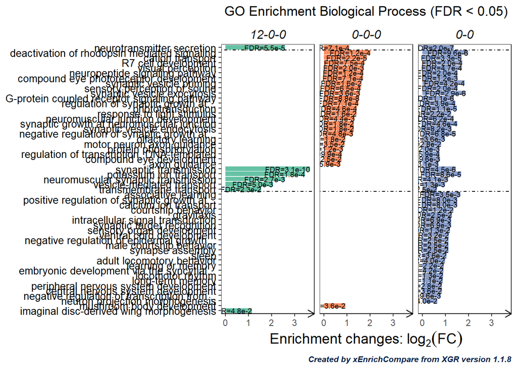

### 1-1 - Translation, protein transport, immune response

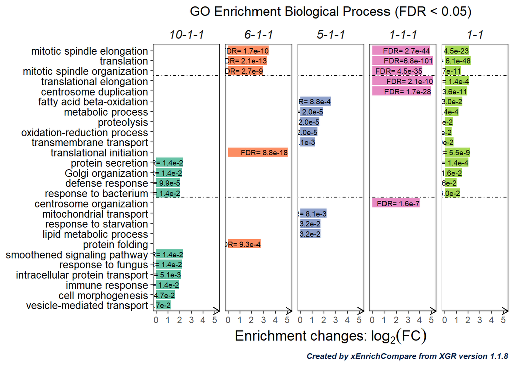

### 2-1 - Sugar metabolism, proteolysis, Krebs Cycle

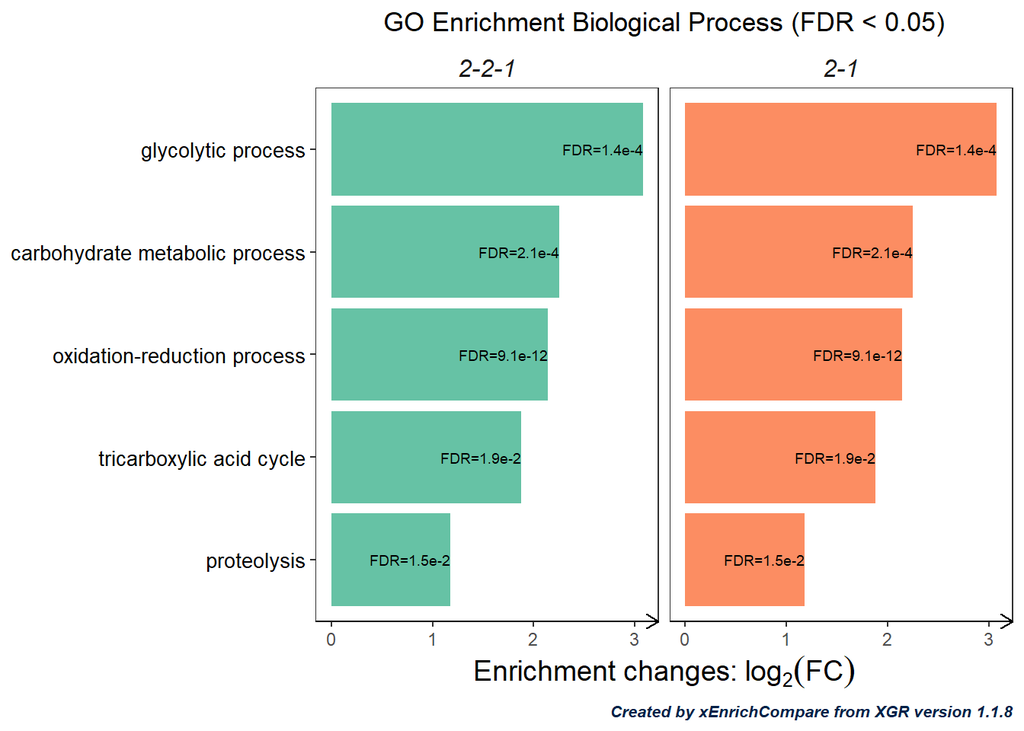

### 3-0 - Development, transcription, splicing, cell respiration

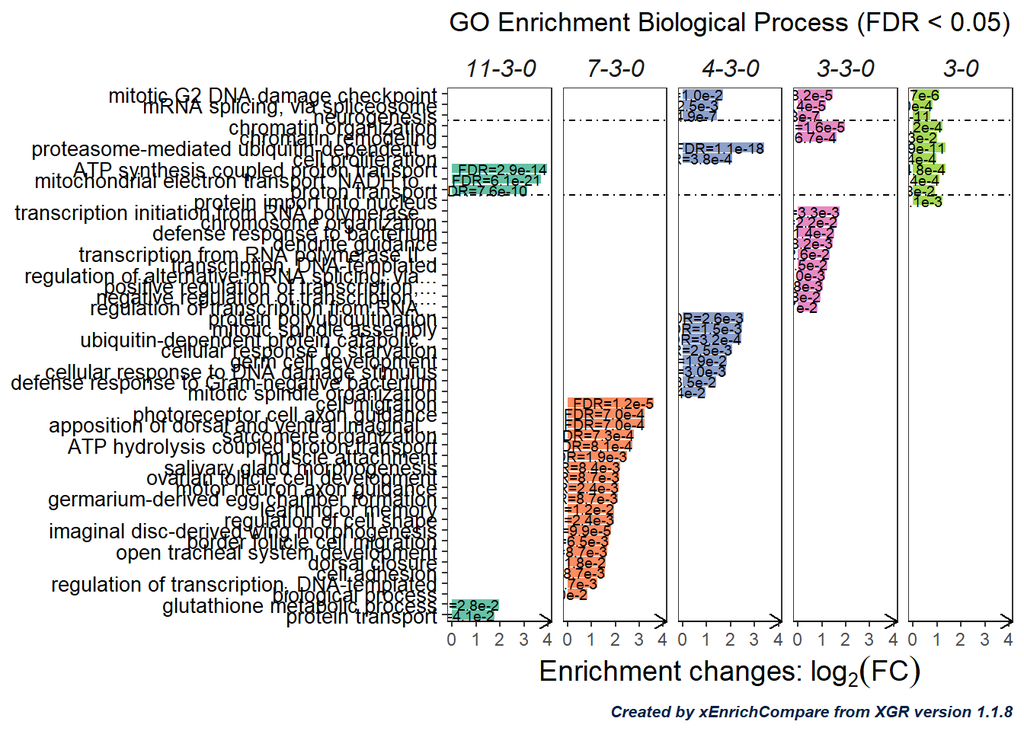

### 4-0 - Muscle delevelopment, krebs cycle

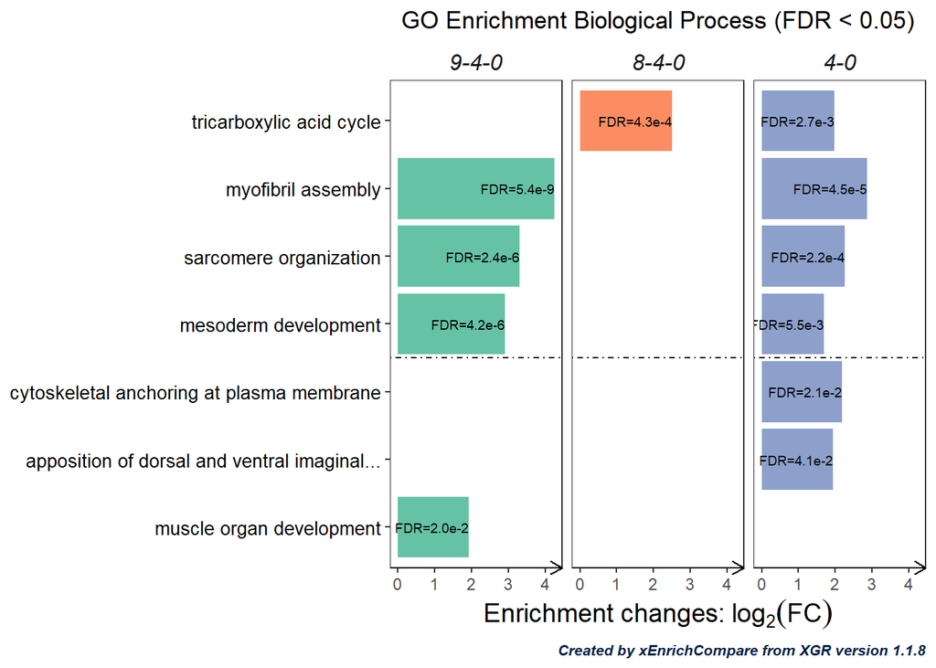

# Probing some interesting blocks

## Neuro

### 0-0-0

```
## [1] "0-0-0"
```

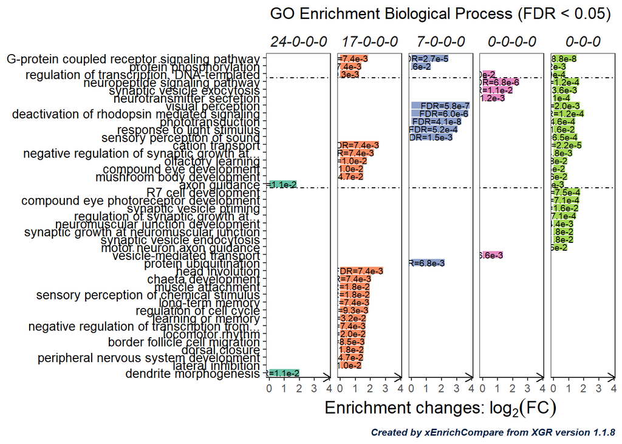

Overall: [Gorilla 0-0-0](http://cbl-gorilla.cs.technion.ac.il/GOrilla/t9225cmq/GOResults.html)

- 24 - Biological regulation, signal transduction, cell component assembly, neuro development [Gorilla](http://cbl-gorilla.cs.technion.ac.il/GOrilla/guawsy78/GOResults.html)
- 17 - Regulation of cellular process [Gorilla](http://cbl-gorilla.cs.technion.ac.il/GOrilla/kqzedrl9/GOResults.html)
- 7 - phototransduction, detection of light stimulus, G protein-coupled receptor signaling pathway [Gorilla](http://cbl-gorilla.cs.technion.ac.il/GOrilla/l41i3m00/GOResults.html)
- 3 - RNA processing [Gorilla](http://cbl-gorilla.cs.technion.ac.il/GOrilla/oyxkgskl/GOResults.html)
- 0 - neuropeptide signaling pathway, synaptic vesicle [transport|localization|exocytosis], synapse [Gorilla](http://cbl-gorilla.cs.technion.ac.il/GOrilla/m3m7vxbz/GOResults.html)

### 12-0-0

```
## [1] "12-0-0"
```

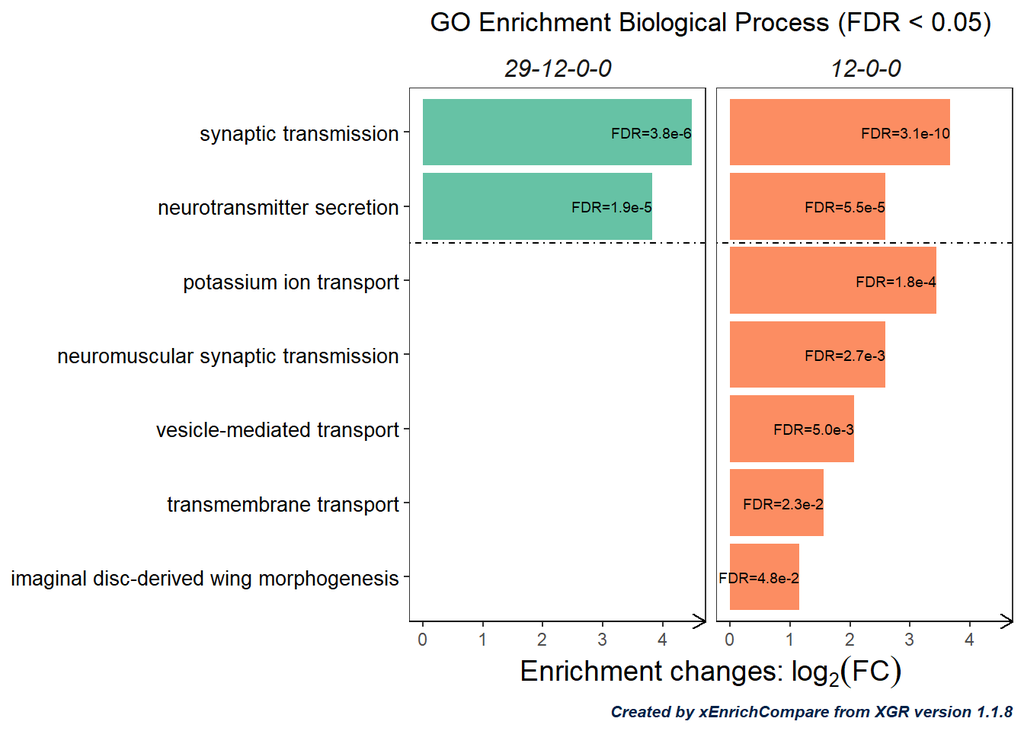

Overall: [Gorilla 12-0-0](http://cbl-gorilla.cs.technion.ac.il/GOrilla/pf4211os/GOResults.html)

- 29 - trans-synaptic signaling [Gorilla](http://cbl-gorilla.cs.technion.ac.il/GOrilla/5rjvkbnh/GOResults.html)
- 37 - [cell|neuron] recognition [Gorilla](http://cbl-gorilla.cs.technion.ac.il/GOrilla/b0f7z1bu/GOResults.html)
- 48 - [reproductive|mating] behavior [Gorilla](http://cbl-gorilla.cs.technion.ac.il/GOrilla/dhry9dhc/GOResults.html)
- 53 - Nada! Zilch! Nothing! [Gorilla](http://cbl-gorilla.cs.technion.ac.il/GOrilla/00a4edhz/GOResults.html)

## Translation

### 1-1-1

```
## [1] "1-1-1"
```

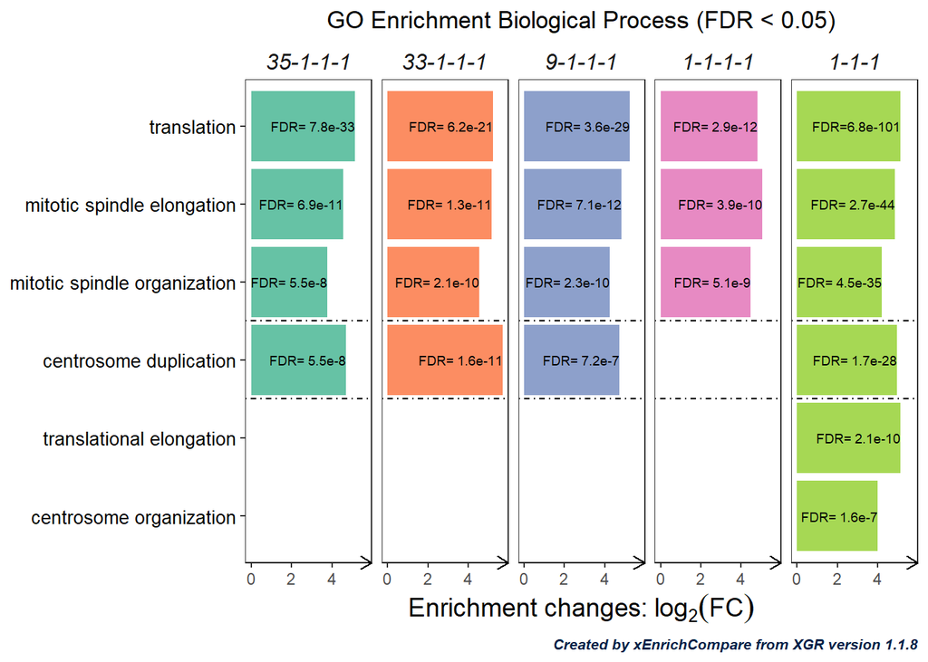

Overall: [Gorilla 1-1-1](http://cbl-gorilla.cs.technion.ac.il/GOrilla/nlj5mvjc/GOResults.html)

- 1 - macromolecule biosynthetic process, translation [Gorilla](http://cbl-gorilla.cs.technion.ac.il/GOrilla/nrzyaooi/GOResults.html)
- 9 - cytoplasmic translation [Gorilla](http://cbl-gorilla.cs.technion.ac.il/GOrilla/8ponxj6c/GOResults.html)
- 33 - cytoplasmic translation, rRNA processing [Gorilla](http://cbl-gorilla.cs.technion.ac.il/GOrilla/hvl0wwk1/GOResults.html)
- 35 - translation, [peptide|peptide] biosynthetic process, ribosomal large subunit assembly [Gorilla](http://cbl-gorilla.cs.technion.ac.il/GOrilla/1ibmyrs2/GOResults.html)

### 6-1-1

```
## [1] "6-1-1"
```

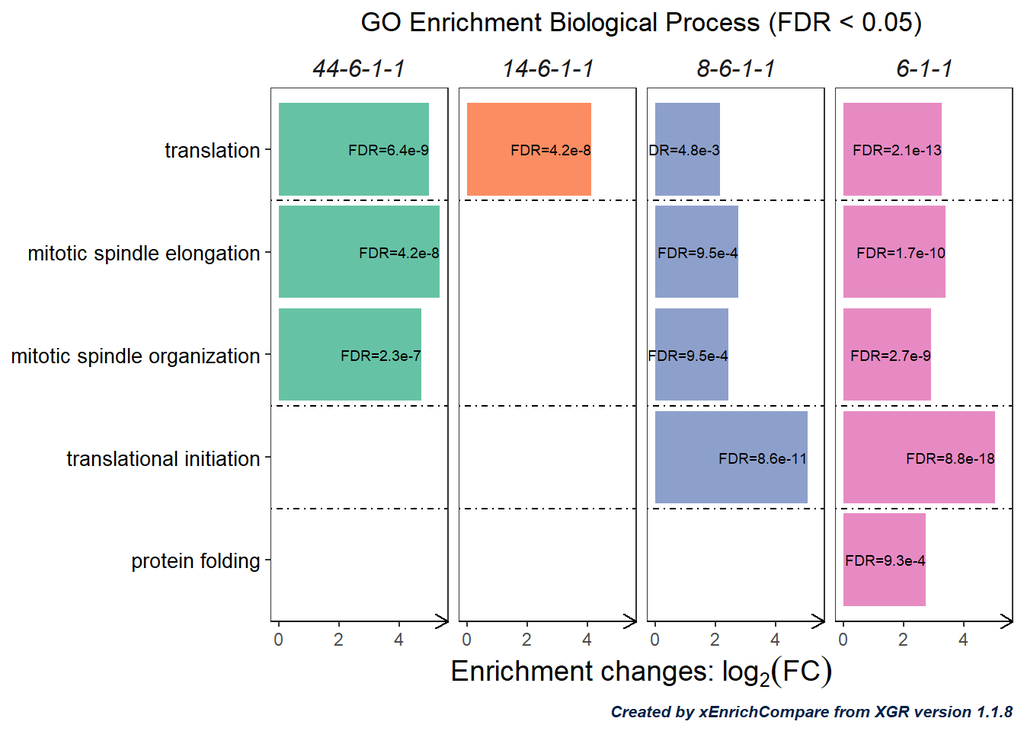

Overall: [Gorilla 6-1-1](http://cbl-gorilla.cs.technion.ac.il/GOrilla/myfdufik/GOResults.html)

- 8 - translational initiation [Gorilla](http://cbl-gorilla.cs.technion.ac.il/GOrilla/q1x8kdjy/GOResults.html)
- 14 - translation, [peptide|peptide biosynthetic process] biosynthetic process, ribonucleoprotein complex subunit organization [Gorilla](http://cbl-gorilla.cs.technion.ac.il/GOrilla/0i8n6vol/GOResults.html)
- 44 - cytoplasmic translation [Gorilla](http://cbl-gorilla.cs.technion.ac.il/GOrilla/bipi9j66/GOResults.html)
- 49 - nucleobase-containing small molecule biosynthetic process (super weak) [Gorilla](http://cbl-gorilla.cs.technion.ac.il/GOrilla/5s5xcg23/GOResults.html)

## Immune response

### 10-1-1

```
## [1] "10-1-1"
```

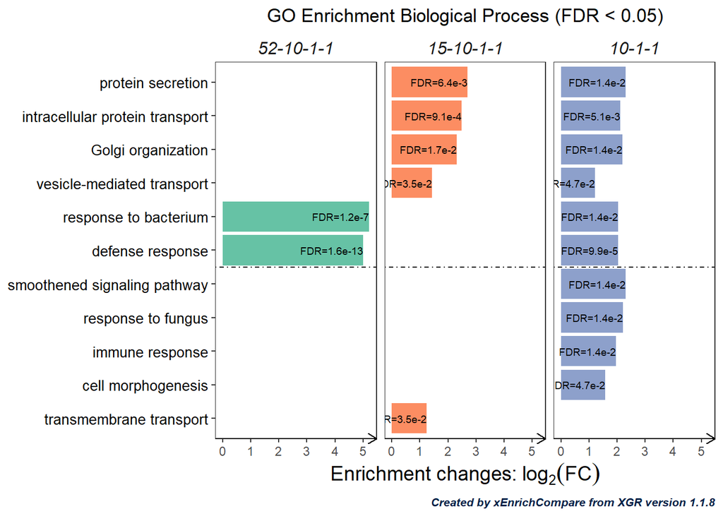

Overall: [Gorilla 10-1-1](http://cbl-gorilla.cs.technion.ac.il/GOrilla/0niexouo/GOResults.html)

- 15 - establishment of protein localization, protein transport [Gorilla](http://cbl-gorilla.cs.technion.ac.il/GOrilla/ojylaaqx/GOResults.html)
- 22 - protein targeting to membrane, translocation [Gorilla](http://cbl-gorilla.cs.technion.ac.il/GOrilla/0w4pu6m4/GOResults.html)
- 52 - response to other organism, response to external biotic stimulus, defense response [Gorilla](http://cbl-gorilla.cs.technion.ac.il/GOrilla/n543uzcv/GOResults.html)

## Cell respiration

### 11-3-0

```
## [1] "11-3-0"
```

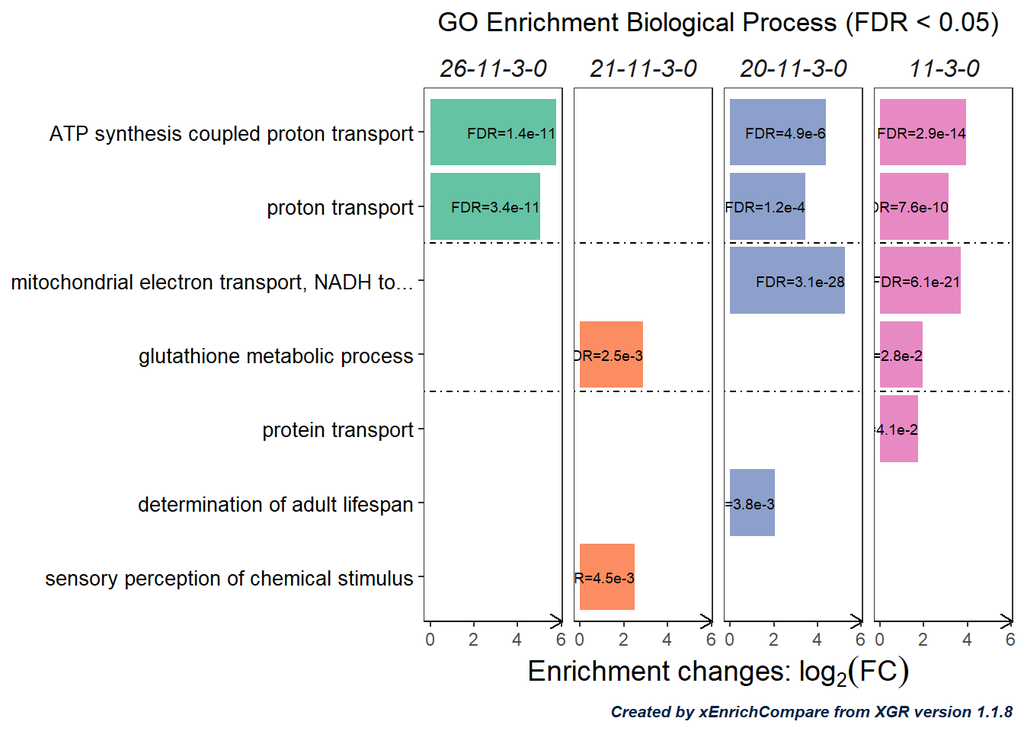

Overall: [Gorilla 11-3-0](http://cbl-gorilla.cs.technion.ac.il/GOrilla/8osn851b/GOResults.html)

- 20 - electron transport chain, generation of precursor metabolites and energy, oxidation-reduction process, mitochondrial respiratory chain complex assembly [Gorilla](http://cbl-gorilla.cs.technion.ac.il/GOrilla/97whbz6e/GOResults.html)
- 21 - multicellular organism reproduction (weak) [Gorilla](http://cbl-gorilla.cs.technion.ac.il/GOrilla/prj4unq1/GOResults.html)
- 26 - purine ribonucleotide biosynthetic process, ATP biosynthetic process, ATP metabolic process, acyl-CoA biosynthetic process [Gorilla](http://cbl-gorilla.cs.technion.ac.il/GOrilla/tkc86ux8/GOResults.html)

## Development

### 7-3-0

```
## [1] "7-3-0"
```

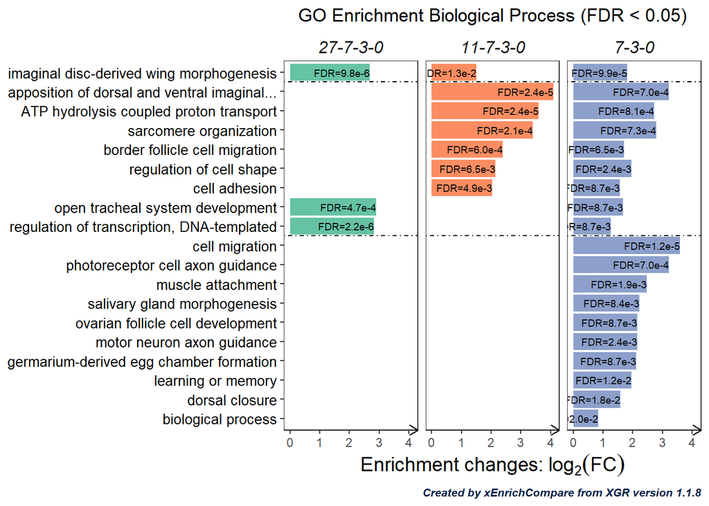

Overall: [Gorilla 7-3-0](http://cbl-gorilla.cs.technion.ac.il/GOrilla/78gpi3iz/GOResults.html)

- 11 - apposition of dorsal and ventral imaginal disc-derived wing surfaces, sarcomere organization, proton transmembrane transport [Gorilla](http://cbl-gorilla.cs.technion.ac.il/GOrilla/j6uasu8e/GOResults.html)
- 27 - anatomical structure morphogenesis, developmental process [Gorilla](http://cbl-gorilla.cs.technion.ac.il/GOrilla/2nnwdok2/GOResults.html)
- 51 - Nothing [Gorilla](http://cbl-gorilla.cs.technion.ac.il/GOrilla/fn7vq86w/GOResults.html)

## Transcription and protein metabolism

### Protein Catabolism

```
## [1] "4-3-0"
```

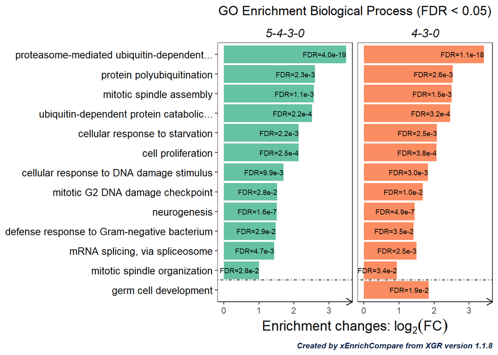

Overall: [Gorilla 4-3-0](http://cbl-gorilla.cs.technion.ac.il/GOrilla/biznpxxr/GOResults.html)

- 5 - protein catabolic process, proteasome-mediated ubiquitin-dependent protein catabolic process, mRNA splicing [Gorilla](http://cbl-gorilla.cs.technion.ac.il/GOrilla/ocor5ovg/GOResults.html)
- 50 - superoxide metabolic process (weak) [Gorilla](http://cbl-gorilla.cs.technion.ac.il/servlet/GOrilla?id=1tkubwji)

### Transcription (and some weird misc)

```
## [1] "3-3-0"
```

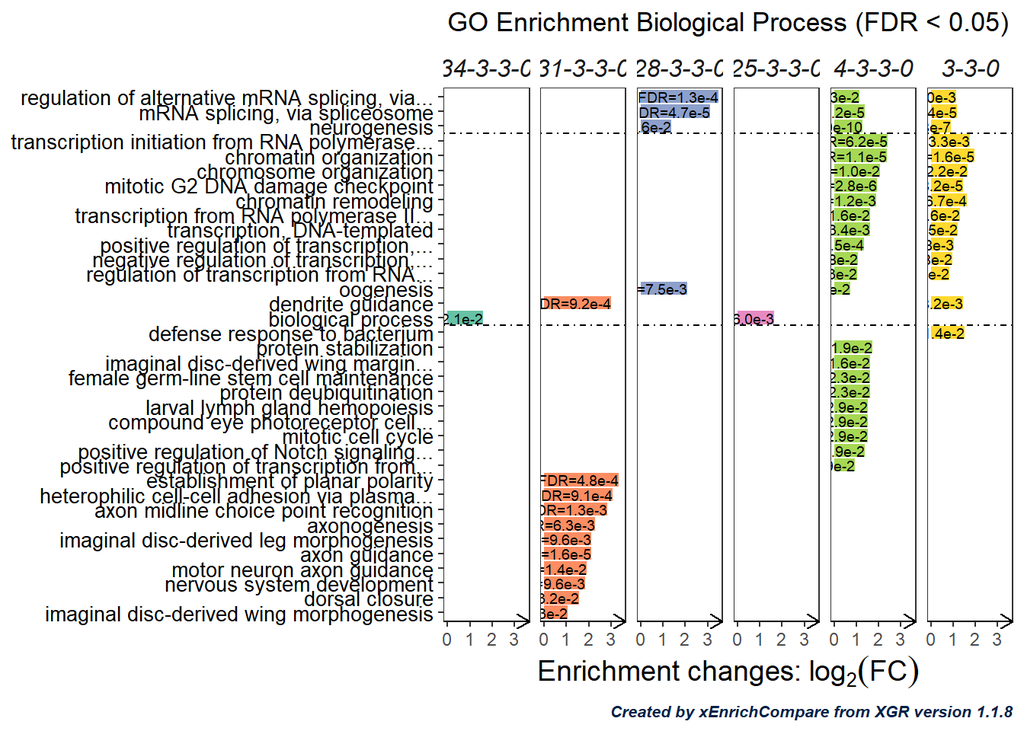

Overall: [Gorilla 3-3-0](http://cbl-gorilla.cs.technion.ac.il/GOrilla/lrmmvnxq/GOResults.html)

- 4 - Largest block (500 genes) - nucleic acid metabolic process, RNA metabolic process, regulation of gene expression [Gorilla](http://cbl-gorilla.cs.technion.ac.il/GOrilla/wzsd5uvj/GOResults.html)
- 25 - renal filtration (weak) [Gorilla](http://cbl-gorilla.cs.technion.ac.il/GOrilla/tn8zdgqm/GOResults.html)
- 28 - regulation of macromolecule metabolic process, regulation of gene expression , mRNA splicing [Gorilla](http://cbl-gorilla.cs.technion.ac.il/GOrilla/98molyys/GOResults.html)
- 31 - axon guidance, cell recognition, neuron projection guidance [Gorilla](http://cbl-gorilla.cs.technion.ac.il/GOrilla/aei7zmpt/GOResults.html)
- 34 - extracellular matrix organization (weak) [Gorilla](http://cbl-gorilla.cs.technion.ac.il/GOrilla/492x8puw/GOResults.html)
- 40 - chitin metabolic process, chitin metabolic process (weak) [Gorilla](http://cbl-gorilla.cs.technion.ac.il/GOrilla/rdj38g2t/GOResults.html)
- 43 - basement membrane organization, cell-substrate adhesion (weak) [Gorilla](http://cbl-gorilla.cs.technion.ac.il/GOrilla/7q6mkafo/GOResults.html)
- 55 - immune response, humoral immune response, defense response to bacterium [Gorilla](http://cbl-gorilla.cs.technion.ac.il/GOrilla/9esgzndl/GOResults.html)

## Block summary table:

```r
dplyr::select(en_head$summary, Nested_Level, Name, N_genes, Internal_degree, Assortativity,  p.adjust, n_enrich)
```

| Nested_Level | Name | N_genes | Internal_degree | Assortativity | p.adjust | n_enrich |
| --- | --- | --- | --- | --- | --- | --- |
| 1 | 0-0-0-0 | 413 | 784 | 9.88656513 | 3.100620e-04 | 27 |
| 1 | 1-1-1-1 | 13 | 156 | -0.07580800 | 4.606846e-11 | 7 |
| 1 | 2-2-2-1 | 21 | 416 | 1.25658726 | 3.593319e-05 | 18 |
| 1 | 3-0-0-0 | 14 | 178 | 1.46034430 | 1.910476e-03 | 13 |
| 1 | 4-3-3-0 | 512 | 678 | 8.70182077 | 2.702723e-14 | 183 |
| 1 | 5-4-3-0 | 227 | 586 | 7.08608481 | 1.565507e-10 | 27 |
| 1 | 6-5-1-1 | 155 | 278 | 1.65360882 | 2.014545e-06 | 24 |
| 1 | 7-0-0-0 | 143 | 744 | 9.70179832 | 3.735163e-12 | 26 |
| 1 | 8-6-1-1 | 42 | 88 | 0.97150035 | 1.876668e-09 | 8 |
| 1 | 9-1-1-1 | 19 | 342 | 1.14089265 | 4.190651e-27 | 9 |

[output cut: 66 more lines]